# Piloting Graph Learning in Adults

```r
library(summarytools, quietly = TRUE)
library(dplyr, quietly = TRUE)
logdir='~/Dropbox/projects/in_progress/network_learning/code/netlearn_kids_v1/logs/'
datadir='~/Dropbox/projects/in_progress/network_learning/code/netlearn_kids_v1/subjData/'
exposureData <- read.delim(paste0(logdir, "NL001/NL001_log_run1.csv"))
seqcmplData <- read.csv(paste0(datadir, "NL001/seqcmpl/NL001_log_seqcmpl.csv"))
omotData<- read.csv(paste0(datadir, "NL001/OMOT/NL001_log_omot.csv"))
seqcmplData$correct <- factor(seqcmplData$correct, ordered=TRUE, labels=c("Incorrect", "Correct"))
```

## Check each assessment for data quality

```r
view(dfSummary(exposureData))
```

```
## Method 'viewer' only valid within RStudio. Switching method to 'browser'.
```

```
## Output file written: /var/folders/m4/l8x9203x15n77thcpm1t4x8m0000gq/T//RtmpHeedyx/file5d6d2685b314.html
```

```r
view(dfSummary(seqcmplData))
```

```
## Method 'viewer' only valid within RStudio. Switching method to 'browser'.
```

```
## Output file written: /var/folders/m4/l8x9203x15n77thcpm1t4x8m0000gq/T//RtmpHeedyx/file5d6d7ec3b74f.html
```

```r
view(dfSummary(omotData))
```

```
## Method 'viewer' only valid within RStudio. Switching method to 'browser'.
```

```
## Output file written: /var/folders/m4/l8x9203x15n77thcpm1t4x8m0000gq/T//RtmpHeedyx/file5d6d4905d065.html
```

```r
summary(exposureData$rt)
```

```
##    Min. 1st Qu.  Median    Mean 3rd Qu.    Max.
##  0.6165  1.4595  2.5906  3.5477  5.1406 16.9147
```

**Does RT go down or up as the task goes on?**

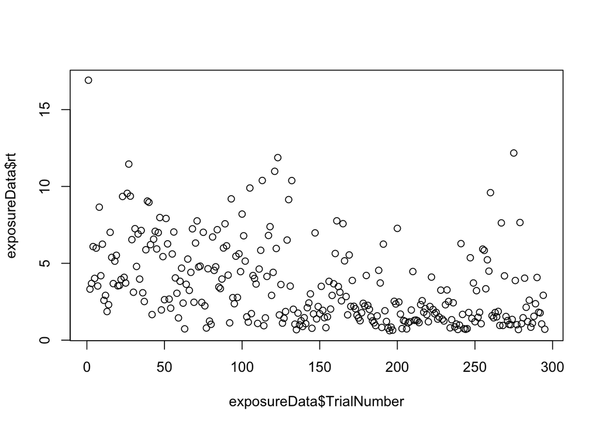

```r
plot(exposureData$TrialNumber, exposureData$rt)
```

```r
cor.test(exposureData$TrialNumber, exposureData$rt)
```

```
##
##  Pearson's product-moment correlation
##
## data:  exposureData$TrialNumber and exposureData$rt
## t = -8.147, df = 293, p-value = 1.089e-14
## alternative hypothesis: true correlation is not equal to 0
## 95 percent confidence interval:
##  -0.5185099 -0.3318477
## sample estimates:
##        cor
## -0.4297593
```

It goes down (not surprisingly)! **Is RT longer after transition nodes?**

```r
exposureData$transition_node <- ifelse((exposureData$node1==4 & exposureData$node2 ==5) |(exposureData$node1 ==5 & exposureData$node2 ==4), 1, 0)
exposureData$transition_node <- factor(exposureData$transition_node, labels=c("No", "Yes"))
exposureData %>%  group_by(transition_node) %>% summarise(avg_rt=mean(rt), med_rt=median(rt), std_dev=sd(rt), n_trials=n())
```

| transition_node | avg_rt | med_rt | std_dev | n_trials |
| --- | --- | --- | --- | --- |
| No | 3.579924 | 2.632000 | 2.607540 | 271 |
| Yes | 3.184428 | 2.350155 | 3.235556 | 24 |

No, in fact it’s shorter–but in this participant, their first 2 trials were on a transition node. Wonder if that influences things? **How long does it take with 300 nodes (of which 4 are practice trials)?**

```r
max(exposureData$onset)/60
```

```
## [1] 27.81883
```

## Sequence Completion Task

How many are correct? 75%.

```r
table(seqcmplData$correct)
```

```
##
## Incorrect   Correct
##         2         6
```

## Odd Man Out Task

```r
view(dfSummary(omotData))
```

```
## Method 'viewer' only valid within RStudio. Switching method to 'browser'.
```

```
## Output file written: /var/folders/m4/l8x9203x15n77thcpm1t4x8m0000gq/T//RtmpHeedyx/file5d6d410962bc.html
```

On average, 89% correct on OMOT.

Does average number correct differ by trial type?

```r
omotData %>% group_by(trial_type) %>% summarise(avg_correct=mean(correct))
```

| trial_type | avg_correct |
| --- | --- |
| catch | 1.0000000 |
| conservative | 1.0000000 |
| non_conservative | 0.7222222 |

**Does RT differ by trial type?**

```r
omotData %>% group_by(trial_type) %>% summarise(avg_rt=mean(rt), med_rt=median(rt), std_dev=sd(rt), n_trials=n())
```

| trial_type | avg_rt | med_rt | std_dev | n_trials |
| --- | --- | --- | --- | --- |
| catch | 8.515418 | 4.073815 | 15.145022 | 12 |
| conservative | 3.207197 | 3.298255 | 1.288933 | 18 |
| non_conservative | 7.188372 | 6.276570 | 4.714416 | 18 |

Average RT is highest in catch trials, lowest in conservative trials, as we would expect. Median RT is highest in non-conservative trials and lowest in conservative trials, again as we would expect.

**Does RT differ by sequence-longer later in the sequence, or shorter?**

```r
cor.test(omotData$TrialNumber, omotData$rt)
```

```
##
##  Pearson's product-moment correlation
##
## data:  omotData$TrialNumber and omotData$rt
## t = -2.471, df = 46, p-value = 0.01724
## alternative hypothesis: true correlation is not equal to 0
## 95 percent confidence interval:
##  -0.5709213 -0.0644507
## sample estimates:
##        cor
## -0.3423167
```

Yes, it’s negative, meaning that RT got faster as they went on.

# Subject 2

```r
exposureData <- read.delim(paste0(logdir, "NL002/NL002_log_run1.csv"))
seqcmplData <- read.csv(paste0(datadir, "NL002/seqcmpl/NL002_log_seqcmpl.csv"))
omotData<- read.csv(paste0(datadir, "NL002/OMOT/NL002_log_omot.csv"))
#seqcmplData$correct <- factor(seqcmplData$correct, ordered=TRUE, levels=c(1,0), labels=c("Incorrect", "Correct"))
#omotData$correct <- factor(omotData$correct, ordered=TRUE, labels=c("Incorrect", "Correct")) #commented out because if make them factors then can't do proportion calculations on them.
```

## Check exposure data quality

```r
view(dfSummary(exposureData))
```

```
## Method 'viewer' only valid within RStudio. Switching method to 'browser'.
```

```
## Output file written: /var/folders/m4/l8x9203x15n77thcpm1t4x8m0000gq/T//RtmpHeedyx/file5d6d47612e80.html
```

```r
summary(exposureData$rt)
```

```
##    Min. 1st Qu.  Median    Mean 3rd Qu.    Max.
## 0.01356 0.94451 1.52300 1.99941 2.72671 7.90344
```

**Does RT go down or up as the task goes on?**

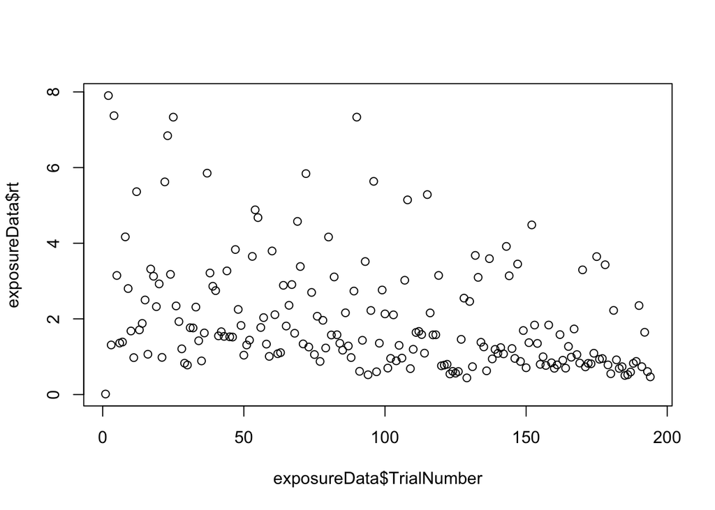

```r
plot(exposureData$TrialNumber, exposureData$rt)
```

```r
cor.test(exposureData$TrialNumber, exposureData$rt)
```

```
##
##  Pearson's product-moment correlation
##
## data:  exposureData$TrialNumber and exposureData$rt
## t = -5.3972, df = 192, p-value = 1.982e-07
## alternative hypothesis: true correlation is not equal to 0
## 95 percent confidence interval:
##  -0.4793152 -0.2340395
## sample estimates:
##        cor
## -0.3629478
```

It goes down (not surprisingly)! **Is RT longer after transition nodes?**

```r
exposureData$transition_node <- ifelse((exposureData$node1==4 & exposureData$node2 ==5) |(exposureData$node1 ==5 & exposureData$node2 ==4), 1, 0)
exposureData$transition_node <- factor(exposureData$transition_node, labels=c("No", "Yes"))
exposureData %>%  group_by(transition_node) %>% summarise(avg_rt=mean(rt), med_rt=median(rt), std_dev=sd(rt), n_trials=n())
```

| transition_node | avg_rt | med_rt | std_dev | n_trials |
| --- | --- | --- | --- | --- |
| No | 1.979292 | 1.42767 | 1.515774 | 178 |
| Yes | 2.223228 | 1.65986 | 1.501722 | 16 |

Yes, it is! **How long does it take with 200 nodes?**

```r
max(exposureData$onset)/60
```

```
## [1] 13.20855
```

## Sequence Completion Task

Data quality

```r
view(dfSummary(seqcmplData))
```

```
## Method 'viewer' only valid within RStudio. Switching method to 'browser'.
```

```
## Output file written: /var/folders/m4/l8x9203x15n77thcpm1t4x8m0000gq/T//RtmpHeedyx/file5d6d3a064d81.html
```

How many are correct? 100%

```r
table(seqcmplData$correct)
```

```
##
## 1
## 8
```

## Odd Man Out Task

```r
view(dfSummary(omotData))
```

```
## Method 'viewer' only valid within RStudio. Switching method to 'browser'.
```

```
## Output file written: /var/folders/m4/l8x9203x15n77thcpm1t4x8m0000gq/T//RtmpHeedyx/file5d6d35360e73.html
```

On average, 58% correct on OMOT.

Does average number correct differ by trial type?

```r
omotData %>% group_by(trial_type) %>% summarise(avg_correct=mean(correct))
```

| trial_type | avg_correct |
| --- | --- |
| catch | 0.7500000 |
| conservative | 0.6111111 |
| non_conservative | 0.4444444 |

The ‘correct’ answer for catch trials is the node that is 2 edges away rather than one edge away, but they are within the same community. 44% is still above chance on the non-conservative trials!

**Does RT differ by trial type?**

```r
omotData %>% group_by(trial_type) %>% summarise(avg_rt=mean(rt), med_rt=median(rt), std_dev=sd(rt), n_trials=n())
```

| trial_type | avg_rt | med_rt | std_dev | n_trials |
| --- | --- | --- | --- | --- |
| catch | 3.100152 | 2.983715 | 1.060527 | 12 |
| conservative | 2.866954 | 2.468675 | 1.642996 | 18 |
| non_conservative | 3.583021 | 3.329830 | 1.987156 | 18 |

Average and median RT is highest in non-conservative trials, lowest in conservative trials, as we would expect.

**Does RT differ by sequence-longer later in the sequence, or shorter?**

```r
cor.test(omotData$TrialNumber, omotData$rt)
```

```
##
##  Pearson's product-moment correlation
##
## data:  omotData$TrialNumber and omotData$rt
## t = -0.91291, df = 46, p-value = 0.366
## alternative hypothesis: true correlation is not equal to 0
## 95 percent confidence interval:
##  -0.4022856  0.1566744
## sample estimates:
##        cor
## -0.1333988
```

```r
exposureData <- read.delim(paste0(logdir, "NL003/NL003_log_run1.csv"))
seqcmplData <- read.csv(paste0(datadir, "NL003/seqcmpl/NL003_log_seqcmpl.csv"))
omotData<- read.csv(paste0(datadir, "NL003/OMOT/NL003_log_omot.csv"))
#seqcmplData$correct <- factor(seqcmplData$correct, ordered=TRUE, levels=c(1,0), labels=c("Incorrect", "Correct"))
#omotData$correct <- factor(omotData$correct, ordered=TRUE, labels=c("Incorrect", "Correct")) #commented out because if make them factors then can't do proportion calculations on them.
```

## Check exposure data quality

```r
view(dfSummary(exposureData))
```

```
## Method 'viewer' only valid within RStudio. Switching method to 'browser'.
```

```
## Output file written: /var/folders/m4/l8x9203x15n77thcpm1t4x8m0000gq/T//RtmpHeedyx/file5d6d284153b6.html
```

```r
summary(exposureData$rt)
```

```
##     Min.  1st Qu.   Median     Mean  3rd Qu.     Max.
##  0.01475  1.25565  2.64585  3.24980  4.51088 12.65570
```

**Does RT go down or up as the task goes on?**

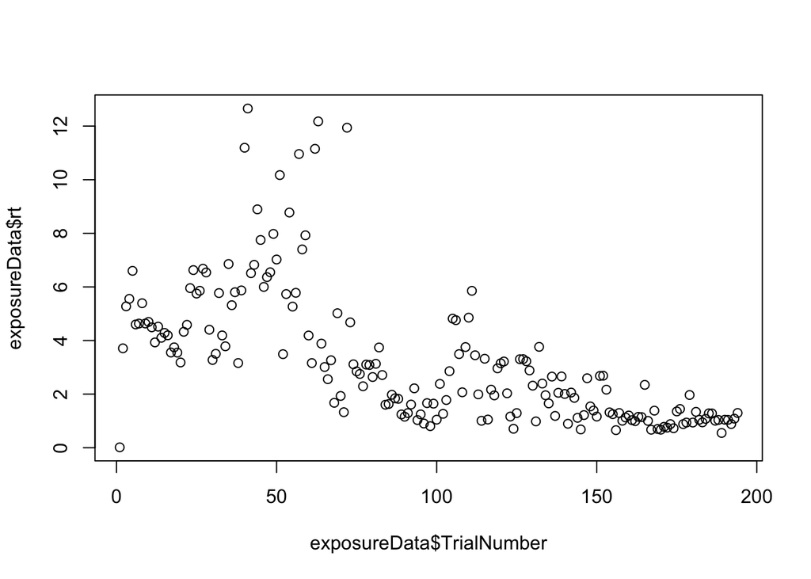

```r
plot(exposureData$TrialNumber, exposureData$rt)
```

```r
cor.test(exposureData$TrialNumber, exposureData$rt)
```

```
##
##  Pearson's product-moment correlation
##
## data:  exposureData$TrialNumber and exposureData$rt
## t = -11.672, df = 192, p-value < 2.2e-16
## alternative hypothesis: true correlation is not equal to 0
## 95 percent confidence interval:
##  -0.7197846 -0.5536031
## sample estimates:
##        cor
## -0.6442349
```

It goes down (not surprisingly)! **Is RT longer after transition nodes?**

```r
exposureData$transition_node <- ifelse((exposureData$node1==4 & exposureData$node2 ==5) |(exposureData$node1 ==5 & exposureData$node2 ==4), 1, 0)
exposureData$transition_node <- factor(exposureData$transition_node, labels=c("No", "Yes"))
exposureData %>%  group_by(transition_node) %>% summarise(avg_rt=mean(rt), med_rt=median(rt), std_dev=sd(rt), n_trials=n())
```

| transition_node | avg_rt | med_rt | std_dev | n_trials |
| --- | --- | --- | --- | --- |
| No | 3.289957 | 2.682445 | 2.476432 | 178 |
| Yes | 2.803052 | 1.287455 | 3.078768 | 16 |

No, it’s not. **How long does it take with 200 nodes?**

```r
max(exposureData$onset)/60
```

```
## [1] 17.28733
```

## Sequence Completion Task

Data quality

```r
view(dfSummary(seqcmplData))
```

```
## Method 'viewer' only valid within RStudio. Switching method to 'browser'.
```

```
## Output file written: /var/folders/m4/l8x9203x15n77thcpm1t4x8m0000gq/T//RtmpHeedyx/file5d6d3b766901.html
```

How many are correct? 88%.

```r
table(seqcmplData$correct)
```

```
##
## 0 1
## 1 7
```

## Odd Man Out Task

```r
view(dfSummary(omotData))
```

```
## Method 'viewer' only valid within RStudio. Switching method to 'browser'.
```

```
## Output file written: /var/folders/m4/l8x9203x15n77thcpm1t4x8m0000gq/T//RtmpHeedyx/file5d6d16d5fd69.html
```

100% correct on OMOT!

Does average number correct differ by trial type?

```r
omotData %>% group_by(trial_type) %>% summarise(avg_correct=mean(correct))
```

| trial_type | avg_correct |
| --- | --- |
| catch | 1 |
| conservative | 1 |
| non_conservative | 1 |

NO difference.

**Does RT differ by trial type?**

```r
omotData %>% group_by(trial_type) %>% summarise(avg_rt=mean(rt), med_rt=median(rt), std_dev=sd(rt), n_trials=n())
```

| trial_type | avg_rt | med_rt | std_dev | n_trials |
| --- | --- | --- | --- | --- |
| catch | 6.996295 | 4.326895 | 8.0043004 | 12 |
| conservative | 2.436863 | 2.349410 | 0.7532468 | 18 |
| non_conservative | 2.523799 | 2.382480 | 0.8545478 | 18 |

Average and median RT is highest in catch trials, lowest in conservative trials.

**Does RT differ by sequence-longer later in the sequence, or shorter?**

```r
cor.test(omotData$TrialNumber, omotData$rt)
```

```
##
##  Pearson's product-moment correlation
##
## data:  omotData$TrialNumber and omotData$rt
## t = -1.1084, df = 46, p-value = 0.2734
## alternative hypothesis: true correlation is not equal to 0
## 95 percent confidence interval:
##  -0.4259037  0.1287479
## sample estimates:
##        cor
## -0.1612869
```